# HUMAN ACTIVITY RECOGNITION USING CNN

## Importing the required libraries

```python
import tensorflow as tf
from tensorflow.keras import Sequential
from tensorflow.keras.layers import Flatten,Dense,Dropout,BatchNormalization
from tensorflow.keras.layers import Conv2D,MaxPool2D
from tensorflow.keras.optimizers import Adam
print(tf.__version__)
```

```
2.1.0
```

```python
import pandas as pd
import numpy as np
import matplotlib.pyplot as plt
from sklearn.model_selection import train_test_split
from sklearn.preprocessing import StandardScaler,LabelEncoder
```

## Load the Dataset

```python
#pd.read_csv('WISDM_ar_v1.1/WISDM_ar_v1.1_raw.txt')
```

The data is not a fully structure and if we try to read this directly into pandas dataframe we won't be able to read this because there are few lines which is actually jiggly wiggly and they have got a mixed up with another line.so it will not load directly into pandas dataframe we need to do some preprocessing before loading this into our data frame.

The above syntax has error so it will not work, because in dataset at line 134634 there are 11 columns instead of 6 columns.

```python
file=open('WISDM_ar_v1.1/WISDM_ar_v1.1_raw.txt')
lines=file.readlines()

processedList=[]

for i,line in enumerate(lines):
    try:
        line=line.split(',')
        last=line[5].split(';')[0]
        last=last.strip()
        if last=='':
            break;
        temp=[line[0],line[1],line[2],line[3],line[4],last]
        processedList.append(temp)
    except:
        print('Error at line number:',i)
```

```
Error at line number: 281873
Error at line number: 281874
Error at line number: 281875
```

As the data is not preprocess properly instead of reading in a data frame we will read it into a native python file application and then we preprocess the file.

In the above cell we have just open the file and reading the file line by line.Then we preprocess a data line by line.And it says that there are 3 error happened while reading this file but this has read all the file in this processed list.

```python
processedList
```

```
[['33', 'Jogging', '49105962326000', '-0.6946377', '12.680544', '0.50395286'],
 ['33', 'Jogging', '49106062271000', '5.012288', '11.264028', '0.95342433'],
 ['33', 'Jogging', '49106112167000', '4.903325', '10.882658', '-0.08172209'],
 ['33', 'Jogging', '49106222305000', '-0.61291564', '18.496431', '3.0237172'],
 ['33', 'Jogging', '49106332290000', '-1.1849703', '12.108489', '7.205164'],
 ['33', 'Jogging', '49106442306000', '1.3756552', '-2.4925237', '-6.510526'],
 ['33', 'Jogging', '49106542312000', '-0.61291564', '10.56939', '5.706926'],
 ['33', 'Jogging', '49106652389000', '-0.50395286', '13.947236', '7.0553403'],
 ['33', 'Jogging', '49106762313000', '-8.430995', '11.413852', '5.134871'],
 ['33', 'Jogging', '49106872299000', '0.95342433', '1.3756552', '1.6480621'],
 ['33', 'Jogging', '49106982315000', '-8.19945', '19.57244', '2.7240696'],
 ['33', 'Jogging', '49107092330000', '1.4165162', '5.7886477', '2.982856'],
 ['33', 'Jogging', '49107202316000', '-1.879608', '-2.982856', '-0.29964766'],
 ['33', 'Jogging', '49107312332000', '-6.1291566', '6.851035', '-8.158588'],
 ['33', 'Jogging', '49107422348000', '5.829509', '18.0061', '8.539958'],
 ['33', 'Jogging', '49107522293000', '6.2789803', '2.982856', '2.9147544'],
 ['33', 'Jogging', '49107632339000', '-1.56634', '8.308413', '-1.4573772'],
 ['33', 'Jogging', '49107742355000', '3.5276701', '13.593107', '9.425281'],
 ['33', 'Jogging', '49107852340000', '-2.0294318', '-5.706926', '-10.18802'],
 ['33', 'Jogging', '49107962326000', '2.7649305', '10.337844', '-9.724928'],
 ['33', 'Jogging', '49108062271000', '3.568531', '13.6748295', '1.5390993'],
 ['33', 'Jogging', '49108172348000', '-0.50395286', '3.8681788', '3.718355'],
 ['33', 'Jogging', '49108272262000', '-2.3018389', '1.6889231', '0.08172209'],
 ['33', 'Jogging', '49108382370000', '-3.568531', '19.57244', '6.510526'],
 ['33', 'Jogging', '49108492294000', '-0.8036005', '-3.2961242', '-4.630918'],
 ['33', 'Jogging', '49108602371000', '0.50395286', '10.841797', '13.525005'],
 ['33', 'Jogging', '49108702285000', '5.706926', '15.595298', '6.1700177'],
 ['33', 'Jogging', '49108812332000', '-8.662541', '7.273266', '4.0180025'],
 ['33', 'Jogging', '49108922378000', '-1.334794', '1.2258313', '2.3699405'],
 ['33', 'Jogging', '49109022293000', '-4.5900574', '19.57244', '4.7126403'],
 ['33', 'Jogging', '49109132308000', '3.8681788', '3.759216', '0.84446156'],
 ['33', 'Jogging', '49109242355000', '-1.7978859', '1.5390993', '8.730643'],
 ['33', 'Jogging', '49109352310000', '7.668256', '11.264028', '-1.3075534'],
 ['33', 'Jogging', '49109462295000', '-2.3699405', '14.2877445', '8.281172'],
 ['33', 'Jogging', '49109562271000', '2.7240696', '1.4573772', '0.88532263'],
 ['33', 'Jogging', '49109672348000', '-3.5957718', '18.659876', '-0.6537767'],
 ['33', 'Jogging', '49109782333000', '3.9499009', '4.140586', '3.990762'],
 ['33', 'Jogging', '49109892349000', '0.46309182', '-2.4108016', '2.4108016'],
 ['33', 'Jogging', '49109992263000', '3.7864566', '14.137921', '-3.1463003'],
 ['33', 'Jogging', '49110102371000', '3.336985', '19.231932', '6.5513873'],
```

[output cut: 1016 more lines]

```
 ['33', 'Walking', '49436052292000', '-3.718355', '14.369467', '12.367276'],
 ['33', 'Walking', '49436162307000', '-5.434519', '13.443283', '0.27240697'],
 ['33', 'Walking', '49436272293000', '-0.5720546', '10.923519', '2.2201166'],
 ['33', 'Walking', '49436382309000', '0.92618364', '10.460427', '-0.42223078'],
 ['33', 'Walking', '49436492294000', '2.4516625', '10.691973', '0.27240697'],
 ['33', 'Walking', '49436602310000', '0.95342433', '15.935807', '1.4573772'],
 ['33', 'Walking', '49436702316000', '-7.6273947', '15.4046135', '0.84446156'],
 ['33', 'Walking', '49436812301000', '2.2201166', '3.7864566', '-1.2666923'],
 ['33', 'Walking', '49436922317000', '-2.5606253', '3.6774938', '0.95342433'],
 ['33', 'Walking', '49437032303000', '-0.38136974', '7.205164', '8.117727'],
 ['33', 'Walking', '49437142318000', '0.7627395', '3.0237172', '-4.630918'],
 ['33', 'Walking', '49437252304000', '-1.7978859', '5.9793324', '-0.9942854'],
 ['33', 'Walking', '49437362289000', '-1.7978859', '8.430995', '-0.10896278'],
 ['33', 'Walking', '49437472305000', '4.6036777', '14.137921', '0.46309182'],
 ...]
```

In the above cell we will see a file is presented and it has userId,activity,timestamp and finally x,y,z data and this is properly formatted data.

```python
columns=['UserId','Activity','Time','X','Y','Z']
```

In the above cell we have created a columns.

```python
data=pd.DataFrame(data=processedList,columns=columns)
data.head()
```

|  | UserId | Activity | Time | X | Y | Z |
| --- | --- | --- | --- | --- | --- | --- |
| 0 | 33 | Jogging | 49105962326000 | -0.6946377 | 12.680544 | 0.50395286 |
| 1 | 33 | Jogging | 49106062271000 | 5.012288 | 11.264028 | 0.95342433 |
| 2 | 33 | Jogging | 49106112167000 | 4.903325 | 10.882658 | -0.08172209 |
| 3 | 33 | Jogging | 49106222305000 | -0.61291564 | 18.496431 | 3.0237172 |
| 4 | 33 | Jogging | 49106332290000 | -1.1849703 | 12.108489 | 7.205164 |

In the above cell we have created pandas dataframe and passes datas and columns and then we viewed first few lines of the data.

```python
data.shape
```

```
(343416, 6)
```

In the above cell we have checked the shape of the data i.e we have 343416 rows and 6 columns

```python
data.info()
```

```
<class 'pandas.core.frame.DataFrame'>
RangeIndex: 343416 entries, 0 to 343415
Data columns (total 6 columns):
 #   Column    Non-Null Count   Dtype
---  ------    --------------   -----
 0   UserId    343416 non-null  object
 1   Activity  343416 non-null  object
 2   Time      343416 non-null  object
 3   X         343416 non-null  object
 4   Y         343416 non-null  object
 5   Z         343416 non-null  object
dtypes: object(6)
memory usage: 15.7+ MB
```

From the above cell we got the other information about the data i.e all the variables are of string type because dtype is object.

In machine learning algorithm we need to convert the value of X,Y,Z and time into numerical data.

```python
data.isnull().sum()
```

```
UserId      0
Activity    0
Time        0
X           0
Y           0
Z           0
dtype: int64
```

In the above cell we have checked if there is any null values present in our data.And we got to know that there is no null value in our dataset.

```python
data['Activity'].value_counts()
```

```
Walking       137375
Jogging       129392
Upstairs       35137
Downstairs     33358
Sitting         4599
Standing        3555
Name: Activity, dtype: int64
```

## Balance this data

we will be selecting 3555 samples from all of other activities and to do that we need to get all these into a different dataframe.

```python
data['X']=data['X'].astype('float')
data['Y']=data['Y'].astype('float')
data['Z']=data['Z'].astype('float')
```

In the above cell we have converted the string values into floating value.

```python
data.info()
```

```
<class 'pandas.core.frame.DataFrame'>
RangeIndex: 343416 entries, 0 to 343415
Data columns (total 6 columns):
 #   Column    Non-Null Count   Dtype
---  ------    --------------   -----
 0   UserId    343416 non-null  object
 1   Activity  343416 non-null  object
 2   Time      343416 non-null  object
 3   X         343416 non-null  float64
 4   Y         343416 non-null  float64
 5   Z         343416 non-null  float64
dtypes: float64(3), object(3)
memory usage: 15.7+ MB
```

In the above code we see that X,Y,Z is into a floating values.

```python
#sampling rate =20hz that's when the data is processed in 20 hertz
fs=20
```

We are going to first plot it for each of these activity.In the raw data sampling rate is 20Hz that means data processed in 20Hz.

```python
activities=data['Activity'].value_counts().index
```

```python
activities
```

```
Index(['Walking', 'Jogging', 'Upstairs', 'Downstairs', 'Sitting', 'Standing'], dtype='object')
```

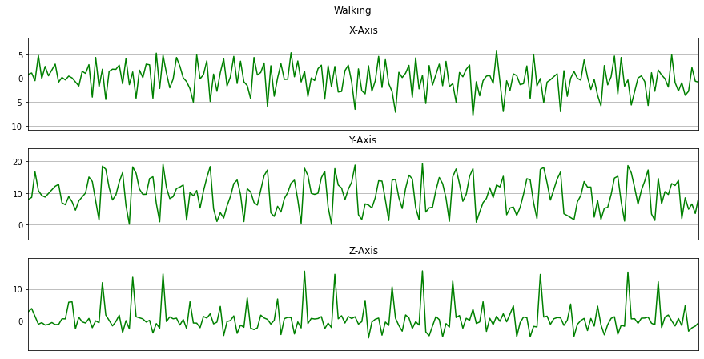

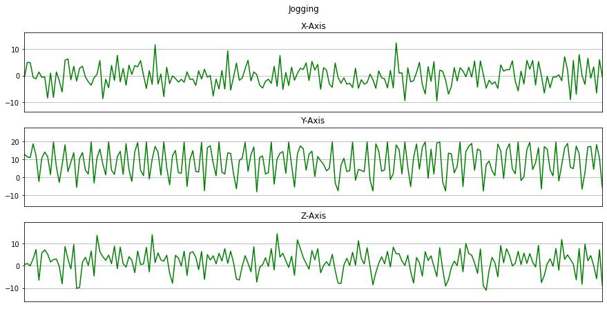

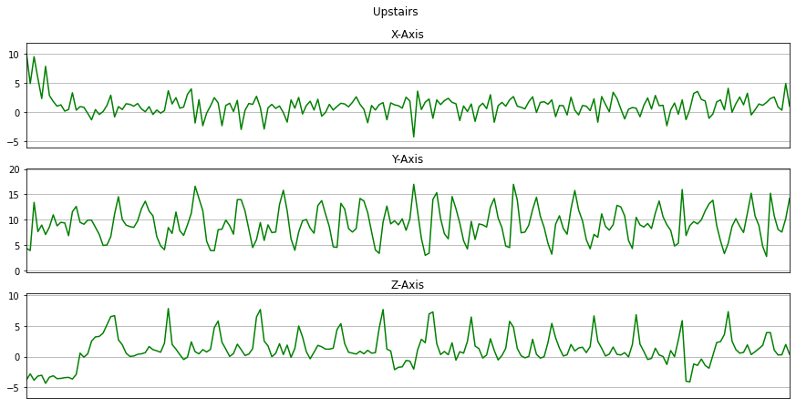

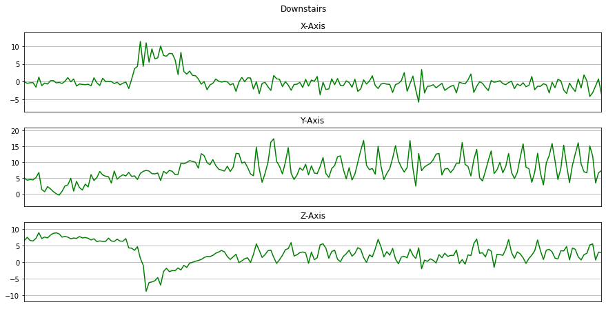

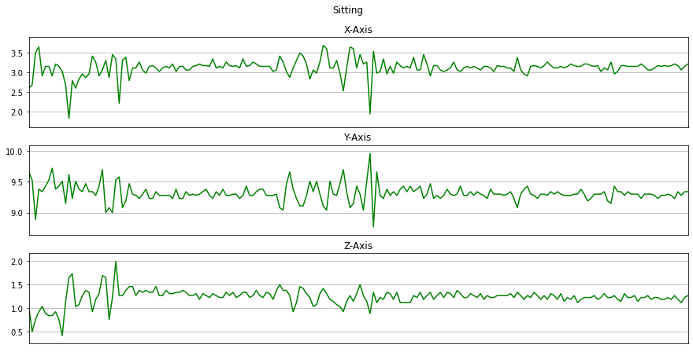

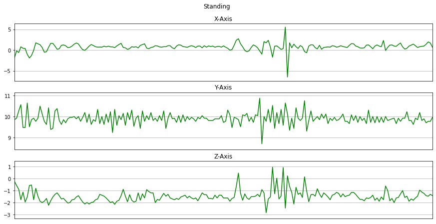

```python
def plot_activity(Activity,data):
    fig,(ax0,ax1,ax2)=plt.subplots(nrows=3,figsize=(15,7),sharex=True)
    plot_axis(ax0,data['Time'],data['X'],'X-Axis')
    plot_axis(ax1,data['Time'],data['Y'],'Y-Axis')
    plot_axis(ax2,data['Time'],data['Z'],'Z-Axis')
    plt.subplots_adjust(hspace=0.2)
    fig.suptitle(Activity)
    plt.subplots_adjust(top=0.90)
    plt.show()

def plot_axis(ax,x,y,title):
    ax.plot(x,y,'g')
    ax.set_title(title)
    ax.xaxis.set_visible(False)
    ax.set_ylim([min(y)-np.std(y),max(y)+np.std(y)])
    ax.set_xlim([min(x),max(x)])
    ax.grid(True)

for Activity in activities:
    data_for_plot=data[(data['Activity']==Activity)][:fs*10]
    plot_activity(Activity,data_for_plot)
```

This is how machine learning will learn if there is much activity then it can classify into jogging and walkingand apart from that if less activity then it can classify into sitting .

```python
#drop user and time
df=data.drop(['UserId','Time'],axis=1).copy()
df.head()
```

|  | Activity | X | Y | Z |
| --- | --- | --- | --- | --- |
| 0 | Jogging | -0.694638 | 12.680544 | 0.503953 |
| 1 | Jogging | 5.012288 | 11.264028 | 0.953424 |
| 2 | Jogging | 4.903325 | 10.882658 | -0.081722 |
| 3 | Jogging | -0.612916 | 18.496431 | 3.023717 |
| 4 | Jogging | -1.184970 | 12.108489 | 7.205164 |

In the above code we have removed the userId and Time then we get a copy of this data frame in to our new dataframe(df) and we viewed first few lines which we will be needing for classification.

```python
df['Activity'].value_counts()
```

```
Walking       137375
Jogging       129392
Upstairs       35137
Downstairs     33358
Sitting         4599
Standing        3555
Name: Activity, dtype: int64
```

This is highly inbalance data.

so we will take only 3555 samples for all other activities as well and to do that we need to make a different dataframe for all these activities and then after that we will append those together.

```python
Walking=df[df['Activity']=='Walking'].head(3555).copy()
Jogging=df[df['Activity']=='Jogging'].head(3555).copy()
Upstairs=df[df['Activity']=='Upstairs'].head(3555).copy()
Downstairs=df[df['Activity']=='Downstairs'].head(3555).copy()
Sitting=df[df['Activity']=='Sitting'].head(3555).copy()
Standing=df[df['Activity']=='Standing'].head(3555).copy()
```

from the above cell we got six different data frame.and we got only of 3555 data samples for all of these activities.

we have balanced our data set and we need to bring all these together in a single dataframe once again.

```python
balanced_data=pd.DataFrame()
balanced_data=balanced_data.append([Walking,Jogging,Upstairs,Downstairs,Sitting,Standing])
```

we called balanced_data dataframe and we appended all other data frames together.

```python
balanced_data.shape
```

```
(21330, 4)
```

from the above cell we got to know about the shape of the dataframe i.e we have 21330 rows and we have 4 columns.

```python
balanced_data['Activity'].value_counts()
```

```
Walking       3555
Sitting       3555
Standing      3555
Jogging       3555
Downstairs    3555
Upstairs      3555
Name: Activity, dtype: int64
```

from the above cell we got to know that data samples are equal for all other activities.

```python
balanced_data.head()
```

|  | Activity | X | Y | Z |
| --- | --- | --- | --- | --- |
| 597 | Walking | 0.844462 | 8.008764 | 2.792171 |
| 598 | Walking | 1.116869 | 8.621680 | 3.786457 |
| 599 | Walking | -0.503953 | 16.657684 | 1.307553 |
| 600 | Walking | 4.794363 | 10.760075 | -1.184970 |
| 601 | Walking | -0.040861 | 9.234595 | -0.694638 |

In the above cell we have viewed first few lines of the balanced dataset.

This activity is in string now we need to convert it into label encoder and to call labelencoder we first need to import the label encoder.

```python
from sklearn.preprocessing import LabelEncoder
```

```python
label=LabelEncoder()
balanced_data['label']=label.fit_transform(balanced_data['Activity'])
```

```python
balanced_data.head()
```

|  | Activity | X | Y | Z | label |
| --- | --- | --- | --- | --- | --- |
| 597 | Walking | 0.844462 | 8.008764 | 2.792171 | 5 |
| 598 | Walking | 1.116869 | 8.621680 | 3.786457 | 5 |
| 599 | Walking | -0.503953 | 16.657684 | 1.307553 | 5 |
| 600 | Walking | 4.794363 | 10.760075 | -1.184970 | 5 |
| 601 | Walking | -0.040861 | 9.234595 | -0.694638 | 5 |

from the above code we got to know that activity is encoded inside the label into categorical variable

If we want to get the classes of the label we can just call classes.

```python
label.classes_
```

```
array(['Downstairs', 'Jogging', 'Sitting', 'Standing', 'Upstairs',
       'Walking'], dtype=object)
```

from the above code we got all classes which is encoding.

X,Y,Z are not having same variance.We need to bring X,Y,Z into same variance that's why we need to standardized our data

## Standardized data

```python
X=balanced_data[['X','Y','Z']]
Y=balanced_data['label']
```

from the above code we got label into faeture space and the output target variable into x and y and y is having perfect balanced data.

```python
scaler=StandardScaler()
X=scaler.fit_transform(X)

Scaled_X=pd.DataFrame(data=X,columns=['X','Y','Z'])
Scaled_X['label']=Y.values

Scaled_X
```

|  | X | Y | Z | label |
| --- | --- | --- | --- | --- |
| 0 | 0.000503 | -0.099190 | 0.337933 | 5 |
| 1 | 0.073590 | 0.020386 | 0.633446 | 5 |
| 2 | -0.361275 | 1.588160 | -0.103312 | 5 |
| 3 | 1.060258 | 0.437573 | -0.844119 | 5 |
| 4 | -0.237028 | 0.139962 | -0.698386 | 5 |
| ... | ... | ... | ... | ... |
| 21325 | -0.470217 | 0.178084 | 0.261019 | 3 |
| 21326 | -0.542658 | 0.193692 | 0.248875 | 3 |
| 21327 | -0.628514 | 0.197593 | 0.261019 | 3 |
| 21328 | -0.781444 | 0.049322 | 0.155768 | 3 |
| 21329 | -0.800225 | 0.267827 | 0.475569 | 3 |

21330 rows × 4 columns

So x,y and z i.e feature space has been scaled and it has been brought down in a single variance so there is not muchvariance shift in between x and y.

# Frame Preparation

```python
import scipy.stats as stats
```

```python
Fs=20
frame_size=Fs*4 #80
hop_size=Fs*2
```

```python
def get_frames(df,frame_size,hop_size):

    N_FEATURES=3

    frames=[]
    labels=[]
    for i in range(0,len(df)-frame_size,hop_size):
        X=df['X'].values[i:i+frame_size]
        Y=df['Y'].values[i:i+frame_size]
        Z=df['Z'].values[i:i+frame_size]

        #Retrieve the most often used label in this segment
        label=stats.mode(df['label'][i:i+frame_size])[0][0]
        frames.append([X,Y,Z])
        labels.append(label)

    #Bring the segments into a better shape
    frames=np.asarray(frames).reshape(-1,frame_size,N_FEATURES)
    labels=np.asarray(labels)

    return frames,labels
```

```python
X,Y=get_frames(Scaled_X,frame_size,hop_size)
```

```python
X.shape
```

```
(532, 80, 3)
```

```python
Y.shape
```

```
(532,)
```

```python
X_train,X_test,Y_train,Y_test=train_test_split(X,Y,test_size=0.2,random_state=0,stratify=Y)
```

```python
X_train.shape
```

```
(425, 80, 3)
```

```python
X_test.shape
```

```
(107, 80, 3)
```

```python
X_train[0].shape
```

```
(80, 3)
```

```python
X_train[0].shape
```

```
(80, 3)
```

```python
X_train=X_train.reshape(425,80,3,1)
X_test=X_test.reshape(107,80,3,1)
```

```python
X_train[0].shape
```

```
(80, 3, 1)
```

```python
X_test[0].shape
```

```
(80, 3, 1)
```

# 2D CNN Model

```python
model=Sequential()
model.add(Conv2D(16,(2,2),activation='relu',input_shape=X_train[0].shape))
model.add(Dropout(0.1))

model.add(Conv2D(32,(2,2),activation='relu'))
model.add(Dropout(0.2))

model.add(Flatten())

model.add(Dense(64,activation='relu'))
model.add(Dropout(0.5))

model.add(Dense(6,activation='softmax'))
```

```python
model.compile(optimizer=Adam(learning_rate=0.001),loss='sparse_categorical_crossentropy',metrics=['accuracy'])
```

```python
history=model.fit(X_train,Y_train,epochs=10,validation_data=(X_test,Y_test),verbose=1)
```

```
Train on 425 samples, validate on 107 samples
```

```python
def plot_learningCurve(history,epochs):
    #plot training &validatio n accuracy values
    epoch_range=range(1,epochs+1)
    plt.plot(epoch_range,history.history['accuracy'])
    plt.plot(epoch_range,history.history['val_accuracy'])
    plt.title('Model Accuracy')
    plt.ylabel('Accuracy')
    plt.xlabel('Epoch')
    plt.legend(['Train','val'],loc='upper left')
    plt.show()

    #plot training and validation loss values
    plt.plot(epoch_range,history.history['loss'])
    plt.plot(epoch_range,history.history['val_loss'])
    plt.title('Model loss')
    plt.ylabel('Loss')
    plt.xlabel('Epoch')
    plt.legend(['Train','val'],loc='upper left')
    plt.show()
```

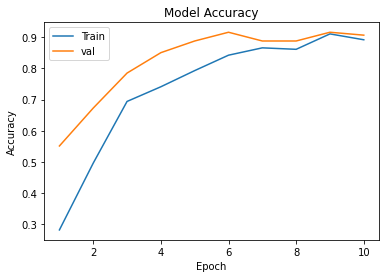

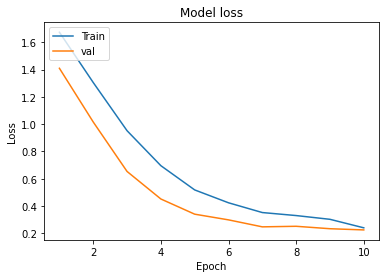

```python
plot_learningCurve(history,10)
```

# Confusion Matrix

```python
from mlxtend.plotting import plot_confusion_matrix
from sklearn.metrics import confusion_matrix
```

```python
Y_pred=model.predict_classes(X_test)
```

[output not shown]

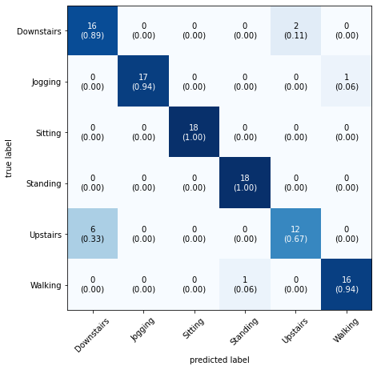

```python
mat =confusion_matrix(Y_test,Y_pred)
plot_confusion_matrix(conf_mat=mat,class_names=label.classes_,show_normed=True,figsize=(7,7))
```

from the above code we get the 100% of accuracy in case of sitting and similarly in case of standing we get 100% accuracy but in case of walking we get just a 94% of the accuracy.In case of upstair ,this upstair is getting confused with the downstair (this is logical upstairs and downstairs could be the same that's why it is getting a little confused so we are getting very low accuracy in upstairs and the downstairs).

Apart from that we are getting perfect accuracy in all other cases like sitting and standing is being classified with 100% accuracy and the walking is with 94% of accuracy in the jogging is also 94% of accuracy.

```python
model.save_weights('model.h5') #with this we can save thsi weight
```